# Abstract

# Literature Review

References:

1. Debadri Dutta, Debpriyo Paul, Parthajeet Ghosh, "Analyzing Feature Importances for Diabetes Prediction using Machine Learning". IEEE, pp 942-928, 2018.
2. K.VijiyaKumar, B.Lavanya, I.Nirmala, S.Sofia Caroline, "Random Forest Algorithm for the Prediction of Diabetes ".Proceeding of International Conference on Systems Compu- tation Automation and Networking, 2019.
3. Md. Faisal Faruque, Asaduzzaman, Iqbal H. Sarker, "Perfor- mance Analysis of Machine Learning Techniques to Predict Diabetes Mellitus". International Conference on Electrical, Computer and Communication Engineering (ECCE), 7-9 Feb- ruary, 2019.
4. Tejas N. Joshi, Prof. Pramila M. Chawan, "Diabetes Prediction Using Machine Learning Techniques".Int. Journal of Engineer- ing Research and Application, Vol. 8, Issue 1, (Part -II) Janu- ary 2018, pp.-09-13
5. Nonso Nnamoko, Abir Hussain, David England, "Predicting Diabetes Onset: an Ensemble Supervised Learning Approach ". IEEE Congress on Evolutionary Computation (CEC), 2018.
6. Deeraj Shetty, Kishor Rit, Sohail Shaikh, Nikita Patil, "Diabe- tes Disease Prediction Using Data Mining ".International Con- ference on Innovations in Information, Embedded and Com- munication Systems (ICIIECS), 2017.
7. Nahla B., Andrew et al,"Intelligible support vector machines for diagnosis of diabetes mellitus. Information Technology in Biomedicine", IEEE Transactions. 14, (July. 2010), 1114-20.
8. A.K., Dewangan, and P., Agrawal, Classification of Diabetes Mellitus Using Machine Learning Techniques, International Journal of Engineering and Applied Sciences, vol. 2, 2015.

# Research Question

How Pregnancies,Age,Glucose,BMI,Blood Pressure factors influence and effect the person causing diabetes.

# Importing Libraries

```python
# Importing libraries
import pandas as pd
import numpy as np
from sklearn.tree import DecisionTreeClassifier
from sklearn.neural_network import MLPClassifier
from sklearn.metrics import accuracy_score
from sklearn.ensemble import GradientBoostingClassifier
from sklearn.ensemble import VotingClassifier
from sklearn.model_selection import cross_val_score
from sklearn.ensemble import RandomForestClassifier
import numpy as np # linear algebra
import pandas as pd # data processing, CSV file I/O (e.g. pd.read_csv)
import matplotlib.pyplot as plt
```

# Data Collection

The dataset used in this report are collected from the below provided website link

https://archive.ics.uci.edu/ml/datasets/diabetes

### Dataset Description

The different columns present in the dataset are:

- Pregnancies -> Number of times Pregnant
- Glucose -> Plasma glucose concentration
- BloodPressure -> Diastolic blood pressure (mm Hg)
- SkinThickness -> Triceps skin fold thickness (mm)
- Insulin -> 2-Hour serum insulin (mu U/ml)
- BMI -> Body Mass Index
- DiabetesPedigreeFunction -> Diabetes pedigree function
- Age -> Age in years
- Outcome -> Whether the lady is diabetic or not, 0 represents the person is not diabetic and 1 represents that the person is diabetic.

# Exploratory Data Analysis and Data Visualization

In this section, we'll perform some fundamental exploratory data analysis to acquire a "feel" for the data. We'll analyze the distributions, correlations, and other properties of the various columns and work to eliminate any null values that may be present.

```python
df = pd.read_csv('diabetes.csv')
```

```python
df.head()
```

|  | Pregnancies | Glucose | BloodPressure | SkinThickness | Insulin | BMI | DiabetesPedigreeFunction | Age | Outcome |
| --- | --- | --- | --- | --- | --- | --- | --- | --- | --- |
| 0 | 6 | 148 | 72 | 35 | 0 | 33.6 | 0.627 | 50 | 1 |
| 1 | 1 | 85 | 66 | 29 | 0 | 26.6 | 0.351 | 31 | 0 |
| 2 | 8 | 183 | 64 | 0 | 0 | 23.3 | 0.672 | 32 | 1 |
| 3 | 1 | 89 | 66 | 23 | 94 | 28.1 | 0.167 | 21 | 0 |
| 4 | 0 | 137 | 40 | 35 | 168 | 43.1 | 2.288 | 33 | 1 |

```python
df.info()
```

```
<class 'pandas.core.frame.DataFrame'>
RangeIndex: 768 entries, 0 to 767
Data columns (total 9 columns):
 #   Column                    Non-Null Count  Dtype
---  ------                    --------------  -----
 0   Pregnancies               768 non-null    int64
 1   Glucose                   768 non-null    int64
 2   BloodPressure             768 non-null    int64
 3   SkinThickness             768 non-null    int64
 4   Insulin                   768 non-null    int64
 5   BMI                       768 non-null    float64
 6   DiabetesPedigreeFunction  768 non-null    float64
 7   Age                       768 non-null    int64
 8   Outcome                   768 non-null    int64
dtypes: float64(2), int64(7)
memory usage: 54.1 KB
```

```python
df.describe().T
```

|  | count | mean | std | min | 25% | 50% | 75% | max |
| --- | --- | --- | --- | --- | --- | --- | --- | --- |
| Pregnancies | 768.0 | 3.845052 | 3.369578 | 0.000 | 1.00000 | 3.0000 | 6.00000 | 17.00 |
| Glucose | 768.0 | 120.894531 | 31.972618 | 0.000 | 99.00000 | 117.0000 | 140.25000 | 199.00 |
| BloodPressure | 768.0 | 69.105469 | 19.355807 | 0.000 | 62.00000 | 72.0000 | 80.00000 | 122.00 |
| SkinThickness | 768.0 | 20.536458 | 15.952218 | 0.000 | 0.00000 | 23.0000 | 32.00000 | 99.00 |
| Insulin | 768.0 | 79.799479 | 115.244002 | 0.000 | 0.00000 | 30.5000 | 127.25000 | 846.00 |
| BMI | 768.0 | 31.992578 | 7.884160 | 0.000 | 27.30000 | 32.0000 | 36.60000 | 67.10 |
| DiabetesPedigreeFunction | 768.0 | 0.471876 | 0.331329 | 0.078 | 0.24375 | 0.3725 | 0.62625 | 2.42 |
| Age | 768.0 | 33.240885 | 11.760232 | 21.000 | 24.00000 | 29.0000 | 41.00000 | 81.00 |
| Outcome | 768.0 | 0.348958 | 0.476951 | 0.000 | 0.00000 | 0.0000 | 1.00000 | 1.00 |

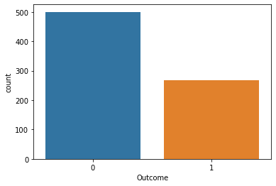

```python
import seaborn as sns
from itertools import cycle
color_cycle = cycle(plt.rcParams['axes.prop_cycle'].by_key()['color'])

sns.countplot(df['Outcome'])
plt.show()
```

```python
df['Outcome'].value_counts()
```

```
0    500
1    268
Name: Outcome, dtype: int64
```

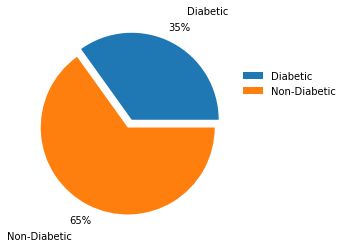

```python
fig, ax = plt.subplots()

labels = ['Diabetic',
         'Non-Diabetic']
percentages = [34.89, 65.10]
explode=(0.1,0)
ax.pie(percentages, explode=explode, labels=labels, autopct='%1.0f%%',
       shadow=False, startangle=0,
       pctdistance=1.2,labeldistance=1.4)
ax.legend(frameon=False, bbox_to_anchor=(1.5,0.8))
plt.show()
```

```python
for col in df.columns:
    print("The minimum value fore the columns {} is {}".format(col, df[col].min()))
```

```
The minimum value fore the columns Pregnancies is 0
The minimum value fore the columns Glucose is 0
The minimum value fore the columns BloodPressure is 0
The minimum value fore the columns SkinThickness is 0
The minimum value fore the columns Insulin is 0
The minimum value fore the columns BMI is 0.0
The minimum value fore the columns DiabetesPedigreeFunction is 0.078
The minimum value fore the columns Age is 21
The minimum value fore the columns Outcome is 0
```

[figure not shown]

```python
fig, axes = plt.subplots(4, 2, figsize=(15, 10))
axes = axes.flatten()
ax_idx = 0
columns = df.drop('Outcome', axis = 1).columns
for col in columns:
    df[col].plot(kind = 'hist', ax = axes[ax_idx], title = col, color = next(color_cycle))
    ax_idx += 1

plt.suptitle('Sales Trend according to Departments')
plt.tight_layout()
plt.show()
```

```python
from scipy.stats import skew
for col in df.drop('Outcome', axis = 1).columns:
    print("Skewness for the column {} is {}".format(col, df[col].skew()))
```

```
Skewness for the column Pregnancies is 0.9016739791518588
Skewness for the column Glucose is 0.17375350179188992
Skewness for the column BloodPressure is -1.8436079833551302
Skewness for the column SkinThickness is 0.10937249648187608
Skewness for the column Insulin is 2.272250858431574
Skewness for the column BMI is -0.42898158845356543
Skewness for the column DiabetesPedigreeFunction is 1.919911066307204
Skewness for the column Age is 1.1295967011444805
```

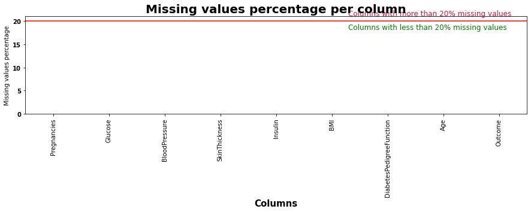

```python
def msv_1(data, thresh = 20, color = 'black', edgecolor = 'black', height = 3, width = 15):

    plt.figure(figsize = (width, height))
    percentage = (data.isnull().mean()) * 100
    percentage.sort_values(ascending = False).plot.bar(color = color, edgecolor = edgecolor)
    plt.axhline(y = thresh, color = 'r', linestyle = '-')

    plt.title('Missing values percentage per column', fontsize=20, weight='bold' )

    plt.text(len(data.isnull().sum()/len(data))/1.7, thresh+2.5, f'Columns with more than {thresh}% missing values', fontsize=12, color='crimson',
         ha='left' ,va='top')
    plt.text(len(data.isnull().sum()/len(data))/1.7, thresh - 0.5, f'Columns with less than {thresh}% missing values', fontsize=12, color='green',
         ha='left' ,va='top')
    plt.xlabel('Columns', size=15, weight='bold')
    plt.ylabel('Missing values percentage')
    plt.yticks(weight ='bold')

    return plt.show()
msv_1(df, 20, color=sns.color_palette('Reds',15))
```

```python
df[['Glucose', 'BloodPressure', 'SkinThickness', 'Insulin', 'BMI']] = df[['Glucose', 'BloodPressure', 'SkinThickness', 'Insulin', 'BMI']].replace(0, np.nan)
```

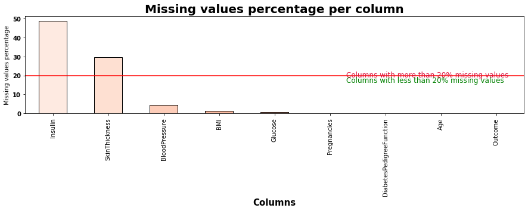

```python
msv_1(df, 20, color=sns.color_palette('Reds',15))
```

```python
df.isnull().sum()
```

```
Pregnancies                   0
Glucose                       5
BloodPressure                35
SkinThickness               227
Insulin                     374
BMI                          11
DiabetesPedigreeFunction      0
Age                           0
Outcome                       0
dtype: int64
```

```python
df['Insulin'] = df['Insulin'].fillna(df['Insulin'].median()) # Filling null values with the median.

for col in ['Glucose', 'BloodPressure', 'SkinThickness', 'BMI']:
    df[col] = df[col].fillna(df[col].mean())
```

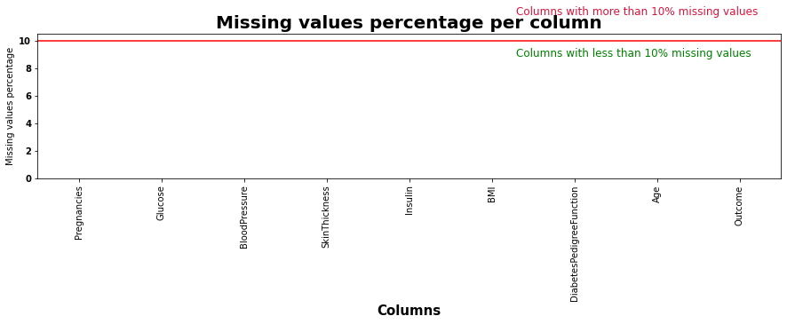

```python
msv_1(df, 10, color=sns.color_palette('Greens',15))
```

```python
def mean_target(var):
    """
    A function that will return the mean values for 'var' column depending on whether the person
    is diabetic or not
    """
    return pd.DataFrame(df.groupby('Outcome').mean()[var])
```

```python
def distplot(col_name):
    """
    A function that will plot the distribution of column 'col_name' for diabetic and non-diabetic people separately
    """
    plt.figure()
    ax = sns.distplot(df[col_name][df.Outcome == 1], color ="red", rug = True)
    sns.distplot(df[col_name][df.Outcome == 0], color ="lightblue",rug = True)
    plt.legend(['Diabetes', 'No Diabetes'])
```

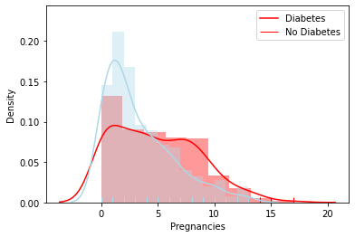

```python
distplot('Pregnancies')
```

```python
mean_target('Pregnancies')
```

| Outcome | Pregnancies |
| --- | --- |
| 0 | 3.298000 |
| 1 | 4.865672 |

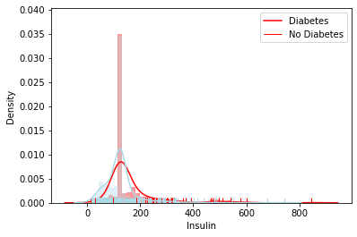

```python
distplot('Insulin')
```

```python
mean_target('Insulin')
```

| Outcome | Insulin |
| --- | --- |
| 0 | 127.792000 |
| 1 | 164.701493 |

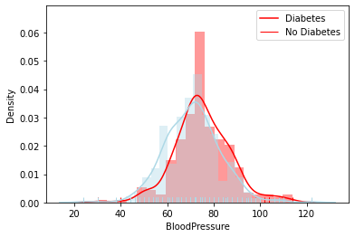

```python
distplot('BloodPressure')
```

```python
mean_target('BloodPressure')
```

| Outcome | BloodPressure |
| --- | --- |
| 0 | 70.935397 |
| 1 | 75.147324 |

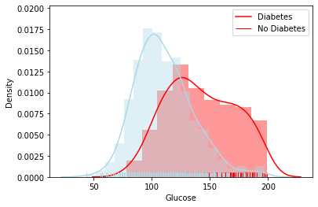

```python
distplot('Glucose')
```

```python
mean_target('Glucose')
```

| Outcome | Glucose |
| --- | --- |
| 0 | 110.710121 |
| 1 | 142.165573 |

# Correlation Matrix

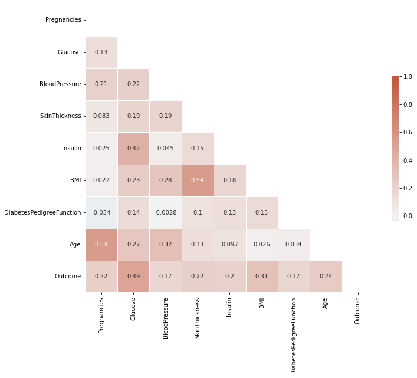

```python
corr = df.corr()

# Generate a mask for the upper triangle
mask = np.triu(np.ones_like(corr, dtype=bool))

# Set up the matplotlib figure
f, ax = plt.subplots(figsize=(11, 9))

# Generate a custom diverging colormap
cmap = sns.diverging_palette(230, 20, as_cmap=True)

# Draw the heatmap with the mask and correct aspect ratio
sns.heatmap(corr, mask=mask, cmap=cmap, vmax=1.0, center=0,
            square=True, linewidths=.5, cbar_kws={"shrink": .5}, annot = True)
```

# Machine Learning Modelling

The machine-learning algorithm voting classifier is used to improve the performance of their model and move up the rank ladder. Voting Classifier has various restrictions but can be used for real-world datasets to increase performance.

The voting classifier aggregates the predicted class or predicted probability on basis of hard voting or soft voting. So if we feed a variety of base models to the voting classifier it makes sure to resolve the error by any model.

It simply aggregates the findings of each classifier passed into Voting Classifier and predicts the output class based on the highest majority of voting. The idea is instead of creating separate dedicated models and finding the accuracy for each them, we create a single model which trains by these models and predicts output based on their combined majority of voting for each output class.

```python
from sklearn.model_selection import train_test_split
```

```python
data=pd.read_csv('diabetes.csv')
```

```python
x = data.drop('Outcome', axis=1)
y = data['Outcome']
print('len of data ',len(data))
train_x,test_x,train_y,test_y=train_test_split(x,y,test_size=100,random_state=0)
```

```
len of data  768
```

```python
train_x,test_x,train_y,test_y=train_test_split(x,y,test_size=100,random_state=0)
```

## MLP Classifier

```python
#Set 1:
mlp1=MLPClassifier(hidden_layer_sizes=100, activation='relu',solver='adam', alpha=0.001, max_iter=500, learning_rate_init=0.001)
mlp1.fit(train_x,train_y)
mlp_pred1=mlp1.predict(test_x)
pred=mlp1.predict(train_x)
print(f"test error {1-accuracy_score(test_y,mlp_pred1)}")
print(f"training error {1-accuracy_score(train_y,pred)}")
```

```
test error 0.31000000000000005
training error 0.2529940119760479
```

```python
#Set 2:
mlp2=MLPClassifier(hidden_layer_sizes=50, activation='logistic',solver='adam', alpha=0.0001, max_iter=300, learning_rate_init=0.01)
mlp2.fit(train_x,train_y)
mlp_pred2=mlp2.predict(test_x)
pred=mlp2.predict(train_x)
print(f'test error {1-accuracy_score(test_y,mlp_pred2)}')
print(f'training error {1-accuracy_score(train_y,pred)}')
```

```
test error 0.26
training error 0.26347305389221554
```

```python
#Set 3:
mlp3=MLPClassifier(hidden_layer_sizes=75, activation='tanh',solver='sgd', alpha=0.001, max_iter=800, learning_rate_init=0.0001)
mlp3.fit(train_x,train_y)
mlp_pred3=mlp3.predict(test_x)
pred=mlp3.predict(train_x)
print(f"test error {1-accuracy_score(test_y,mlp_pred3)}")
print(f'traininig error {1-accuracy_score(train_y,pred)}')
```

```
test error 0.26
traininig error 0.2889221556886228
```

```python
#Set 4:
mlp4=MLPClassifier(hidden_layer_sizes=90,activation='tanh',solver='adam',max_iter=1000, alpha=1, random_state=0)
mlp4.fit(train_x,train_y)
mlp_pred4=mlp4.predict(test_x)
pred=mlp4.predict(train_x)
print(f'test error {1-accuracy_score(test_y,mlp_pred4)}')
print(f'traininig error {1-accuracy_score(train_y,pred)}')
```

```
test error 0.21999999999999997
traininig error 0.20059880239520955
```

```python
#Set 5:
mlp5=MLPClassifier(hidden_layer_sizes=10,activation='identity',max_iter=900, alpha=1, random_state=0)
mlp5.fit(train_x,train_y)
mlp_pred5=mlp5.predict(test_x)
pred=mlp5.predict(train_x)
print(f'test error {1-accuracy_score(test_y,mlp_pred5)}')
print(f'traininig error {1-accuracy_score(train_y,pred)}')
```

```
test error 0.32999999999999996
traininig error 0.31586826347305386
```

## Decision Trees

```python
#Set 1:
dt1=DecisionTreeClassifier( criterion='gini', splitter='best', max_depth=None, min_samples_split=2,  max_features=None, random_state=None, max_leaf_nodes=None)
dt1.fit(train_x,train_y)
dt_pred1=dt1.predict(test_x)
pred=dt1.predict(train_x)
print(f'test error {1-accuracy_score(test_y,dt_pred1)}')
print(f'traininig error {1-accuracy_score(train_y,pred)}')
```

```
test error 0.28
traininig error 0.0
```

```python
#Set 2:
dt2=DecisionTreeClassifier( criterion='entropy', splitter='random', max_depth=10, min_samples_split=5,  max_features=2, random_state=0, max_leaf_nodes=3)
dt2.fit(train_x,train_y)
dt_pred2=dt2.predict(test_x)
pred=dt2.predict(train_x)
print(f'test error {1-accuracy_score(test_y,dt_pred2)}')
print(f'traininig error {1-accuracy_score(train_y,pred)}')
```

```
test error 0.31000000000000005
traininig error 0.35029940119760483
```

```python
#Set 3:
dt3=DecisionTreeClassifier( criterion='gini', splitter='random', max_depth=100, min_samples_split=20,  max_features=3, random_state=1, max_leaf_nodes=300)
dt3.fit(train_x,train_y)
dt_pred3=dt3.predict(test_x)
pred=dt3.predict(train_x)

print(f'test error {1-accuracy_score(test_y,dt_pred3)}')
print(f'traininig error {1-accuracy_score(train_y,pred)}')
```

```
test error 0.25
traininig error 0.19610778443113774
```

```python
#Set 4:
dt4=DecisionTreeClassifier( criterion='gini', splitter='best', max_depth=100, min_samples_split=200,  max_features=4, random_state=1, max_leaf_nodes=300)
dt4.fit(train_x,train_y)
dt_pred4=dt4.predict(test_x)
pred=dt4.predict(train_x)
print(f'test error {1-accuracy_score(test_y,dt_pred4)}')
print(f'traininig error {1-accuracy_score(train_y,pred)}')
```

```
test error 0.28
traininig error 0.25598802395209586
```

```python
#Set 5:
dt5=DecisionTreeClassifier( criterion='entropy', splitter='random', max_depth=400, min_samples_split=300,  max_features=5, random_state=1, max_leaf_nodes=300)
dt5.fit(train_x,train_y)
dt_pred5=dt5.predict(test_x)
pred=dt5.predict(train_x)
print(f'test error {1-accuracy_score(test_y,dt_pred5)}')
print(f'traininig error {1-accuracy_score(train_y,pred)}')
```

```
test error 0.26
traininig error 0.3023952095808383
```

## Random Forest

```python
#Set 1:
rf1=RandomForestClassifier(n_estimators=100, criterion='gini', max_depth=None, min_samples_split=2, max_features='auto')
rf1.fit(train_x,train_y)
rf_pred1=rf1.predict(test_x)
pred=rf1.predict(train_x)
print(f'test error {1-accuracy_score(test_y,rf_pred1)}')
print(f'traininig error {1-accuracy_score(train_y,pred)}')
```

```
test error 0.20999999999999996
traininig error 0.0
```

```python
#Set 2:
rf2=RandomForestClassifier(n_estimators=1000, criterion='entropy', max_depth=100, min_samples_split=5, max_features='auto')
rf2.fit(train_x,train_y)
rf_pred2=rf2.predict(test_x)
pred=rf2.predict(train_x)
print(f'test error {1-accuracy_score(test_y,rf_pred2)}')
print(f'traininig error {1-accuracy_score(train_y,pred)}')
```

```
test error 0.18999999999999995
traininig error 0.0029940119760478723
```

```python
#Set 3:
rf3=RandomForestClassifier(n_estimators=1000, criterion='entropy', max_depth=10, min_samples_split=20, max_features='sqrt')
rf3.fit(train_x,train_y)
rf_pred3=rf3.predict(test_x)
pred=rf3.predict(train_x)
print(f'test error {1-accuracy_score(test_y,rf_pred3)}')
print(f'traininig error {1-accuracy_score(train_y,pred)}')
```

```
test error 0.18000000000000005
traininig error 0.10029940119760483
```

```python
#Set 4:
rf4=RandomForestClassifier(n_estimators=10, criterion='gini', max_depth=5000, min_samples_split=100, max_features='log2')
rf4.fit(train_x,train_y)
rf_pred4=rf4.predict(test_x)
pred=rf4.predict(train_x)
print(f'test error {1-accuracy_score(test_y,rf_pred4)}')
print(f'traininig error {1-accuracy_score(train_y,pred)}')
```

```
test error 0.22999999999999998
traininig error 0.2065868263473054
```

```python
#Set 5:
rf5=RandomForestClassifier(n_estimators=50, criterion='gini', max_depth=100, min_samples_split=2, max_features='auto')
rf5.fit(train_x,train_y)
rf_pred5=rf5.predict(test_x)
pred=rf5.predict(train_x)
print(f'test error {1-accuracy_score(test_y,rf_pred5)}')
print(f'traininig error {1-accuracy_score(train_y,pred)}')
```

```
test error 0.18000000000000005
traininig error 0.0014970059880239361
```

## Gradient boosting classifier

```python
#Set 1:
gb1=GradientBoostingClassifier(loss='deviance', learning_rate=0.1, n_estimators=100, subsample=1.0, criterion='friedman_mse', min_samples_split=2, min_samples_leaf=1)
gb1.fit(train_x,train_y)
gb_pred1=gb1.predict(test_x)
pred=gb1.predict(train_x)
print(f'test error {1-accuracy_score(test_y,gb_pred1)}')
print(f'traininig error {1-accuracy_score(train_y,pred)}')
```

```
test error 0.18999999999999995
traininig error 0.08383233532934131
```

```python
##Set 2:
gb2=GradientBoostingClassifier(loss='exponential', learning_rate=0.01, n_estimators=500, subsample=1.0, criterion='squared_error', min_samples_split=5, min_samples_leaf=5)
gb2.fit(train_x,train_y)
gb_pred2=gb2.predict(test_x)
pred=gb2.predict(train_x)
print(f'test error {1-accuracy_score(test_y,gb_pred2)}')
print(f'traininig error {1-accuracy_score(train_y,pred)}')
```

```
test error 0.20999999999999996
traininig error 0.13323353293413176
```

```python
##Set 3:
gb3=GradientBoostingClassifier(loss='deviance', learning_rate=0.001, n_estimators=1000, subsample=1.0, criterion='absolute_error', min_samples_split=20, min_samples_leaf=5)
gb3.fit(train_x,train_y)
gb_pred3=gb3.predict(test_x)
pred=gb3.predict(train_x)
print(f'test error {1-accuracy_score(test_y,gb_pred3)}')
print(f'traininig error {1-accuracy_score(train_y,pred)}')
```

```
test error 0.19999999999999996
traininig error 0.2425149700598802
```

```python
#Set 4:
gb4=GradientBoostingClassifier(loss='exponential', learning_rate=0.01, n_estimators=10, subsample=1.0, criterion='squared_error', min_samples_split=22, min_samples_leaf=93)
gb4.fit(train_x,train_y)
gb_pred4=gb4.predict(test_x)
pred=gb4.predict(train_x)
print(f'test error {1-accuracy_score(test_y,gb_pred4)}')
print(f'traininig error {1-accuracy_score(train_y,pred)}')
```

```
test error 0.31000000000000005
traininig error 0.35479041916167664
```

```python
#Set 5:
gb5=GradientBoostingClassifier(loss='deviance', learning_rate=0.01, n_estimators=50, subsample=1.0, criterion='absolute_error', min_samples_split=90, min_samples_leaf=44)
gb5.fit(train_x,train_y)
gb_pred5=gb5.predict(test_x)
pred=gb5.predict(train_x)
print(f'test error {1-accuracy_score(test_y,gb_pred5)}')
print(f'traininig error {1-accuracy_score(train_y,pred)}')
```

```
test error 0.31000000000000005
traininig error 0.35479041916167664
```

## With equal weight to each classifier, i.e. 1/4*g1+1/4*g2+1/4*g3+1/4*g4

```python
eclf = VotingClassifier(
...     estimators=[('mlp', mlp1), ('dt',dt3 ), ('rf',rf3),('gb', gb1)],
...     voting='hard',weights=[1, 1, 1,1])

for clf, label in zip([mlp1,dt3,rf3,gb1,eclf], ['Multilayer perceptron','decision tree','random forest','gradient Boost','Ensemble']):

    scores = cross_val_score(clf, train_x, train_y, scoring='accuracy', cv=5)
    print("Training Error: %0.2f [%s]" % (1-scores.mean(),label))

    scores_test = cross_val_score(clf, test_x, test_y, scoring='accuracy', cv=5)
    print("Testing Error: %0.2f [%s]" % (1-scores_test.mean(),label))
```

```
Training Error: 0.30 [Multilayer perceptron]
```

```
Testing Error: 0.29 [Multilayer perceptron]
Training Error: 0.29 [decision tree]
Testing Error: 0.25 [decision tree]
Training Error: 0.24 [random forest]
Testing Error: 0.28 [random forest]
Training Error: 0.25 [gradient Boost]
Testing Error: 0.28 [gradient Boost]
Training Error: 0.24 [Ensemble]
```

```
Testing Error: 0.27 [Ensemble]
```

## b) With weights proportional to 1/(1+trainingerror)

```python
mlp_pred=mlp1.predict(train_x)
dt_pred=dt3.predict(train_x)
gb_pred=gb1.predict(train_x)
rf_pred=rf3.predict(train_x)
```

```python
mlp_error=1-accuracy_score(train_y,mlp_pred)
dt_error=1-accuracy_score(train_y,dt_pred)
gb_error=1-accuracy_score(train_y,gb_pred)
rf_error=1-accuracy_score(train_y,rf_pred)
print(mlp_error)
print(dt_error)
print(gb_error)
print(rf_error)
```

```
0.2529940119760479
0.19610778443113774
0.08383233532934131
0.10029940119760483
```

```python
eclf = VotingClassifier(
...     estimators=[('mlp', mlp1), ('dt',dt3 ),('rf',rf3), ('gb', gb1)],
...     voting='hard',weights=[1/(1+mlp_error), 1/(1+dt_error),1/(1+rf_error) ,1/(1+gb_error)])
for clf, label in zip([mlp5, dt4, gb2,rf5, eclf], ['Multilayer perceptron', 'Decision Tree','random forest', 'gradient Boosting', 'Ensemble']):
...     scores = cross_val_score(clf, train_x, train_y, scoring='accuracy', cv=5)
...     print("Training Error: %0.2f  [%s]" % (1-scores.mean(), label))

    scores_test = cross_val_score(clf, test_x, test_y, scoring='accuracy', cv=5)
    print("Testing Error: %0.2f [%s]" % (1-scores_test.mean(),label))
    print("\n")
```

```
Training Error: 0.32  [Multilayer perceptron]
Testing Error: 0.24 [Multilayer perceptron]


Training Error: 0.29  [Decision Tree]
Testing Error: 0.31 [Decision Tree]


Training Error: 0.24  [random forest]
Testing Error: 0.28 [random forest]


Training Error: 0.24  [gradient Boosting]
Testing Error: 0.27 [gradient Boosting]


Training Error: 0.25  [Ensemble]
```

```
Testing Error: 0.26 [Ensemble]
```

# Results and Conclusion

Our analysis, visualzation as well as the machine learning model is created to support the research question and hypothesis.But after all the analysis, we can conclude that the patient who suffer from diabetes have following characteristics than those who do not suffer.

They are older

They have high glucose level

They have high blood pressure

They have high bmi

They have high diabetes pedigree function